# THSS 730 - Lab 4

Confidence Intervals and Hypothesis Testing

```r
# Necessary libraries
library(tidyverse)
library(readxl)
library(glue)
```

## Chi-Square Distribution

If $X \sim N(\mu, \sigma^2)$, we may need to consider the sampling variance of $X$, which is often denoted as $S^2$. It turns out this statistic follows a random distribution:
$$S^2 \sim \frac{\sigma^2 \chi^2_{n-1}}{n-1}$$

Note I’m using $S$ instead of lower case $s$ because it’s common to use capital letters when denoting a random variable and lower case letters when denoting an observed value of that random variable.

The chi-square ($\chi^2$) distribution:

- Has one parameter: degrees of freedom (df)
- Only takes on positive values and is always skewed to the right
- The skewness diminishes as the degrees of freedom increase

In R, we can calculate probabilities and percentiles of the chi-square distribution using `pchisq()` and `qchisq()` functions.

```r
# Cumulative probability
pchisq(1, df = 9)
```

```
[1] 0.0005624973
```

```r
# Upper tail probability
1 - pchisq(3, df = 9)
```

```
[1] 0.964295
```

```r
# Percentiles (quantiles)
qchisq(0.975, df = 9)
```

```
[1] 19.02277
```

```r
qchisq(0.025, df = 9)
```

```
[1] 2.700389
```

## F Distribution

If you have two independent samples from a $N(\mu_1, \sigma_1^2)$ and $N(\mu_2, \sigma_2^2)$ distribution, respectively, then under $H_0: \sigma_1^2 = \sigma_2^2$,
$$\frac{S_1^2}{S_2^2} \sim F_{(n_1 - 1, n_2 - 1)}$$

The F distribution: - Has two parameters: numerator degrees of freedom (ndf) and denominator degrees of freedom (ddf) - Only takes on positive values and is generally skewed to the right - The skewness depends on the relative magnitudes of the two degrees of freedom

For the F distribution, we use `pf()` and `qf()` functions in R.

```r
# Cumulative probability for F distribution
pf(1, df1 = 19, df2 = 9)
```

```
[1] 0.4725596
```

```r
# Upper tail probability for F distribution
pf(1, df1 = 19, df2 = 9, lower.tail = FALSE)
```

```
[1] 0.5274404
```

```r
# Percentiles (quantiles)
qf(0.975, df1 = 19, df2 = 9)
```

```
[1] 3.683338
```

```r
qf(0.025, df1 = 19, df2 = 9)
```

```
[1] 0.3472159
```

## Plotting Probability Density Functions (PDFs)

We can use `ggplot2` to plot the PDFs for the chi-square and F distributions for different degrees of freedom.

### Chi-Square Distribution Plot

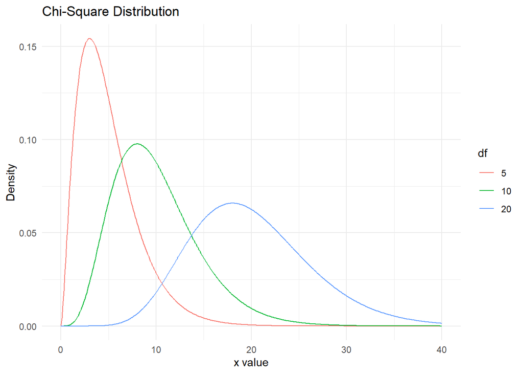

```r
# Create data for chi-square PDF
x <- seq(0, 40, by  = 0.1)
df5 <- dchisq(x, df = 5)
df10 <- dchisq(x, df = 10)
df20 <- dchisq(x, df = 20)

chi_data <- data.frame(
  x = rep(x, 3),
  density = c(df5, df10, df20),
  df = factor(rep(c(5, 10, 20), each = length(x)))
)

ggplot(chi_data, aes(x = x, y = density, color = df)) +
  geom_line() +
  labs(title = "Chi-Square Distribution", x = "x", y = "Density") +
  theme_minimal() +
  labs(x = "x value", y = "Density")
```

### F-Distribution Plot

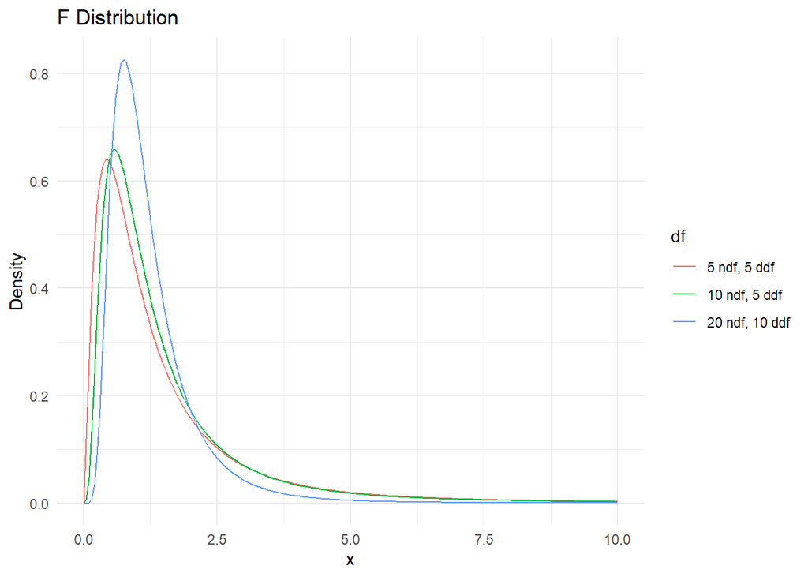

```r
# Create data for F-distribution PDF

x <- seq(0, 10, by = 0.05)
f5_5 <- df(x, df1 = 5, df2 = 5)
f10_5 <- df(x, df1 = 10, df2 = 5)
f20_10 <- df(x, df1 = 20, df2 = 10)

f_data <- data.frame(
  x = rep(x, 3),
  density = c(f5_5, f10_5, f20_10),
  df = factor(rep(c("5 ndf, 5 ddf",
                    "10 ndf, 5 ddf",
                    "20 ndf, 10 ddf"),
                  each = length(x)))
) %>%
  mutate(df = fct_inorder(df))

ggplot(f_data, aes(x = x, y = density, color = df)) +
  geom_line() +
  labs(title = "F Distribution", x = "x", y = "Density") +
  theme_minimal()
```

## Confidence intervals

A 100% x (1-$\alpha$) confidence interval for $\sigma^2$ is given by:

$$\left[ \frac{(n-1)s^2}{\chi^2_{n-1,1-\alpha/2}}, \frac{(n-1)s^2}{\chi^2_{n-1,\alpha/2}} \right]$$

To obtain a $100\% \times (1 - \alpha)$ confidence interval for $\sigma$, take the square root of the confidence limits.

**NOTE:** These confidence intervals for $\sigma^2$ and $\sigma$ are only valid for normally distributed data.

An approximate $100\% \times (1 - \alpha)$ confidence interval for the binomial parameter $p$ based on the normal approximation to the binomial distribution is given by:

$$\hat{p} \pm z_{(1 - \alpha/2)} \sqrt{\frac{\hat{p} \cdot \hat{q}}{n}}$$

or equivalently,

$$\left( \hat{p} - z_{(1 - \alpha/2)} \sqrt{\frac{\hat{p} \cdot\hat{q}}{n}}, \hat{p} + z_{(1 - \alpha/2)} \sqrt{\frac{\hat{p} \cdot\hat{q}}{n}} \right)$$

This is sometimes called the Wald method and is appropriate when $n \cdot \hat{p} \cdot \hat{q} \geq 5$.

When the normal approximation is not appropriate, exact binomial probabilities can be used to construct an exact confidence interval for p. This is sometimes called the Clopper-Pearson method.

Going back now to the “lowbwt.xlsx” example. Recall that the data set has the following variables:

- `sbp` = systolic blood pressure
- `sex` = sex (1=male; 0=female)
- `tox` = toxemia diagnosis for mother (1=yes; 0=no)
- `grmhem` = germinal matrix hemorrhage (1=yes; 0=no)
- `gestage` = gestational age
- `apgar5` = apgar score at 5 minutes

```r
lowbwt <- read_xlsx('data/lowbwt.xlsx')
lowbwt
```

| sbp | sex | tox | grmhem | gestage | apgar5 |
| --- | --- | --- | --- | --- | --- |
| 43 | 1 | 0 | 0 | 29 | 7 |
| 51 | 1 | 0 | 0 | 31 | 8 |
| 42 | 0 | 0 | 0 | 33 | 0 |
| 39 | 0 | 0 | 0 | 31 | 8 |
| 48 | 0 | 1 | 0 | 30 | 7 |
| 31 | 1 | 0 | 1 | 25 | 0 |
| 31 | 1 | 1 | 0 | 27 | 7 |
| 40 | 0 | 0 | 0 | 29 | 9 |
| 57 | 0 | 0 | 0 | 28 | 6 |
| 64 | 0 | 1 | 0 | 29 | 9 |

[output cut: 90 more lines]

Suppose we want to estimate the variance of SBP among low birthweight infants. Here is how we can get both the point estimate and approximate confidence interval.

```r
sbp <- lowbwt$sbp

# number of observations
n <- length(sbp)

# sample variance s^2
var_sbp <- var(sbp)

# CI level
alpha <- 0.05

lwr <- (n - 1) * var_sbp / qchisq(1 - alpha/2, df = n - 1)
upr <- (n - 1) * var_sbp / qchisq(alpha/2, df = n - 1)

# R has a package called glue that lets you splice R objects
# into text using {}. It's very convenient for point and
# interval summaries

var_sbp <- round(var_sbp, digits = 0)
lwr <- round(lwr, digits = 0)
upr <- round(upr, digits = 0)

glue("the variance (95% CI) of SBP is {var_sbp} ({lwr}, {upr})")
```

```
the variance (95% CI) of SBP is 130 (100, 175)
```

Now suppose we want to estimate the proportion of mothers of low birthweight infants who have a toxemia diagnosis during pregnancy. You can get both the point estimate and confidence interval from `binom.test`.

```r
# change the 1 in the line below to a 0 if you want
# to compute the proportion without tox
n_tox <- sum(lowbwt$tox == 1)

# note I defined n in the code chunk above.
# changing conf.level to, e.g., 0.90 would give 90% confidence intervals
tox_result <- binom.test(n_tox, n = n, conf.level = 0.95)

# you can see the results here:

tox_result$estimate
```

```
probability of success
                  0.21
```

```r
tox_result$conf.int
```

```
[1] 0.1349437 0.3029154
attr(,"conf.level")
[1] 0.95
```

```r
# but whoever reviews your work will appreciate a nicely formatted answer.

est <- round(tox_result$estimate, digits = 2)
lwr <- round(tox_result$conf.int[1], digits = 2)
upr <- round(tox_result$conf.int[2], digits = 2)

glue("The proportion (95% CI) is {est} ({lwr}, {upr})")
```

```
The proportion (95% CI) is 0.21 (0.13, 0.3)
```

## Hypothesis Testing

Steps:

1. State the hypotheses (both null and alternative)
2. Specify the significance level ($\alpha$)
3. Compute the test statistic
4. Determine p-value
5. Compare p-value to the significance level $\alpha$ and decide whether or not to reject the null hypothesis ($H_0$)
6. State conclusions in terms of subject matter

### One sample tests

| Test | Null Hypothesis |
| --- | --- |
| **Mean (μ)** |  |
| One-sample t test (σ not known) | H₀: μ = μ₀ |
| One-sample z test (σ known) | H₀: μ = μ₀ |
| **Variance (σ²)** |  |
| One-sample χ² test (only use when data are normal) | H₀: σ² = σ₀² |
| **Proportion (p)** |  |
| One-sample normal | H₀: p = p₀ |
| One-sample exact | H₀: p = p₀ |

Suppose the mean SBP for newborns in the general population is 70 mm Hg. Is the mean SBP for low birthweight infants different than the general population?

```r
# One-sample t-test, making use of the sbp vector we made above
t_test_sbp <- t.test(sbp, mu = 70)

# printing the output from the test (all of it)

t_test_sbp
```

```
    One Sample t-test

data:  sbp
t = -20.1, df = 99, p-value < 2.2e-16
alternative hypothesis: true mean is not equal to 70
95 percent confidence interval:
 44.81735 49.34265
sample estimates:
mean of x
    47.08
```

```r
# printing just the results from the test we are interested in

t_test_sbp$estimate
```

```
mean of x
    47.08
```

```r
t_test_sbp$conf.int
```

```
[1] 44.81735 49.34265
attr(,"conf.level")
[1] 0.95
```

```r
est <- round(t_test_sbp$estimate, digits = 0)
lwr <- round(t_test_sbp$conf.int[1], digits = 0)
upr <- round(t_test_sbp$conf.int[2], digits = 0)

glue("Mean SBP is {est} (95% CI: {lwr}, {upr})")
```

```
Mean SBP is 47 (95% CI: 45, 49)
```

```r
# p-value from null hypothesis of mu = 70
t_test_sbp$p.value
```

```
[1] 1.014499e-36
```

Suppose that 5% of mothers experience toxemia during pregnancy in the general population. Is the proportion of mothers of low birthweight infants who experience toxemia different than the general population?

```r
tox_result <- binom.test(n_tox, n = n, conf.level = 0.95, p = 0.05)

# raw results

tox_result$estimate
```

```
probability of success
                  0.21
```

```r
tox_result$conf.int
```

```
[1] 0.1349437 0.3029154
attr(,"conf.level")
[1] 0.95
```

```r
tox_result$p.value
```

```
[1] 2.081061e-08
```

```r
# formatted

est <- round(tox_result$estimate, digits = 2)
lwr <- round(tox_result$conf.int[1], digits = 2)
upr <- round(tox_result$conf.int[2], digits = 2)


glue(
  "The estimated proportion of mothers with toxemia during \\
     pregnancy was {est} (95% CI: {lwr}, {upr}). \\
     Testing whether the estimate is equal to 0.05 yields a p-value \\
     of <0.001"
)
```

```
The estimated proportion of mothers with toxemia during pregnancy was 0.21 (95% CI: 0.13, 0.3). Testing whether the estimate is equal to 0.05 yields a p-value of <0.001
```

### Two sample tests

| Test | Null Hypothesis |
| --- | --- |
| **Mean (μ) – Paired Samples** |  |
| Paired t test | H₀: Δ = 0 |
| **Mean (μ) – Independent Samples** |  |
| Two-sample t test – equal variances | H₀: μ₁ = μ₂ |
| Two-sample t test – unequal variances | H₀: μ₁ = μ₂ |
| **Variance (σ²) – Independent Normal Samples** |  |
| F test | H₀: σ₁² = σ₂² |

The degree of clinical agreement among physicians on the presence or absence of generalized lymphadenopathy was assessed in 32 randomly selected participants from a prospective study of male sexual contacts of men with acquired immunodeficiency syndrome (AIDS) or an AIDS-related condition (ARC). The total number of palpable lymph nodes was assessed by each of three physicians. Results from two of the three physicians are presented in `lymph_nodes.xlsx`.

```r
lymph_nodes <- read_xlsx("data/lymph_nodes.xlsx")

lymph_nodes
```

| ID | DocA | DocB | Diff |
| --- | --- | --- | --- |
| 1 | 4 | 1 | 3 |
| 2 | 17 | 9 | 8 |
| 3 | 3 | 2 | 1 |
| 4 | 11 | 13 | -2 |
| 5 | 12 | 9 | 3 |
| 6 | 5 | 2 | 3 |
| 7 | 5 | 6 | -1 |
| 8 | 6 | 3 | 3 |
| 9 | 3 | 0 | 3 |
| 10 | 5 | 0 | 5 |

[output cut: 22 more lines]

The data set has the following variables:

- `ID` = patient ID
- `DocA` = number of palpable lymph nodes found by Doctor A
- `DocB` = number of palpable lymph nodes found by Doctor B
- `Diff` = DocA - DocB

Is there a difference between the assessments of Doctor A vs. Doctor B? Assume the sample size is large enough to rely on the CLT.

```r
t_test_diff <- t.test(lymph_nodes$Diff)

# note: this is equivalent to:
t_test_diff <- t.test(x = lymph_nodes$DocA,
                      y = lymph_nodes$DocB,
                      paired = TRUE)

t_test_diff
```

```
    Paired t-test

data:  lymph_nodes$DocA and lymph_nodes$DocB
t = 5.5, df = 31, p-value = 5.12e-06
alternative hypothesis: true mean difference is not equal to 0
95 percent confidence interval:
 1.730243 3.769757
sample estimates:
mean difference
           2.75
```

Returning back to the `lowbwt` data set, suppose we want to know if SBP differs between males and females.

```r
t_test_sbp_by_sex <- with(
  lowbwt,
  t.test(x = sbp[sex == 1],
         y = sbp[sex == 0],
         paired = FALSE)
)

t_test_sbp_by_sex
```

```
    Welch Two Sample t-test

data:  sbp[sex == 1] and sbp[sex == 0]
t = 0.60298, df = 89.858, p-value = 0.548
alternative hypothesis: true difference in means is not equal to 0
95 percent confidence interval:
 -3.211290  6.009991
sample estimates:
mean of x mean of y
 47.86364  46.46429
```

## Extra practice

Use the “lowbwt.xlsx” data set for these problems.

1. Suppose we are interested in the proportion of low birthweight infants who are female.
1. Provide a point estimate and 95% confidence interval.

```r
# don't bother with approximations if it's trivial to do the exact test.

binom_test <- binom.test(x = sum(lowbwt$sex==0), n = nrow(lowbwt))

binom_test
```

```
    Exact binomial test

data:  sum(lowbwt$sex == 0) and nrow(lowbwt)
number of successes = 56, number of trials = 100, p-value = 0.2713
alternative hypothesis: true probability of success is not equal to 0.5
95 percent confidence interval:
 0.4571875 0.6591640
sample estimates:
probability of success
                  0.56
```

2. Assume that in the general population, 50% of infants are female. Is the proportion of female infants different for the low birthweight population? Use a hypothesis test to answer this question.

```r
# exact test

binom_test <- binom.test(x = sum(lowbwt$sex==0), n = nrow(lowbwt), p = 0.50)

binom_test$p.value
```

```
[1] 0.271253
```

```r
# approximation

p <- mean(lowbwt$sex == 0)
n <- nrow(lowbwt)

mu <- n * p

sigma <- sqrt(n * p * (1 - p))

z <- (mu - 50) / sigma

pval <- 2 * pnorm(z, lower.tail = FALSE)

# Approximation is pretty off here. Another good reason not to do it.
pval
```

```
[1] 0.2267649
```

2. Does mean SBP differ between infants whose mothers had toxemia during pregnancy and infants whose mothers did not have toxemia? Assume SBP is normally distributed. Use a hypothesis test to answer this question. Also report the 95% confidence interval that corresponds to the test.

```r
variances <- lowbwt %>%
  group_by(tox) %>%
  summarize(s2 = var(sbp), df = n() - 1)

fstat <- variances$s2[1] / variances$s2[2]

# fstat is >1 so pvalue is 2 * area to the right of fstat

pval_equal_variance <-  2 * pf(q = fstat,
                               df1 = variances$df[1],
                               df2 = variances$df[2],
                               lower.tail = FALSE)

# not enough evidence to conclude variances are not equal
# (note: this is sort of arbitrary - is this sample large enough
#  to detect differences in variance??)

# carry out the t-test with equal variances

t_test_sbp_tox <- with(
  lowbwt,
  t.test(x = sbp[tox == 1],
         y = sbp[tox == 0],
         paired = FALSE,   # two sample test
         var.equal = TRUE) # equal variances
)

t_test_sbp_tox
```

```
    Two Sample t-test

data:  sbp[tox == 1] and sbp[tox == 0]
t = 0.73721, df = 98, p-value = 0.4628
alternative hypothesis: true difference in means is not equal to 0
95 percent confidence interval:
 -3.499971  7.637403
sample estimates:
mean of x mean of y
 48.71429  46.64557
```